# Train a PLIER model on the NARES data

**J. Taroni 2018**

The NARES study was published in the following article:

> Grayson PC, Steiling K, Platt M, et al. [Defining the Nasal Transcriptome in Granulomatosis with Polyangiitis](https://doi.org/10.100art.39185). *Arthritis & Rheumatology*, 2015. doi: 10.1002/art.39185.

We processed this data in the [`greenelab/rheum-data-plier`](https://github.com/greenelab/rheum-plier-data) repo.

This dataset (`n = 76`) contains nasal brushing samples from patients with granulomatosis with polyangiitis (GPA), a form of ANCA-associated vasculitis. Patients with GPA either had active, a prior history of, or no history of nasal disease. A composite comparator group of patients with sarcoidosis, patients with allergic rhinitis and healthy controls is also included.

Here we’ll train a PLIER model and explore:

- The sparsity of the U matrix
- How many LVs are recovered? How many pathways?
- What are the pathways that are represented?

## Libraries

```r
library(AnnotationDbi)
library(PLIER)
```

## NARES data

```r
nares.data <- readr::read_tsv(file.path("data", "expression_data",
                                         "NARES_SCANfast_ComBat.pcl"))
symbol.obj <- org.Hs.eg.db::org.Hs.egSYMBOL
```

```r
mapped.genes <- AnnotationDbi::mappedkeys(symbol.obj)
symbol.list <- as.list(symbol.obj[mapped.genes])
symbol.df <- as.data.frame(cbind(names(symbol.list), unlist(symbol.list)))
colnames(symbol.df) <- c("EntrezID", "GeneSymbol")
# get gene column name to match to facilitate use with dplyr
colnames(nares.data)[1] <- "EntrezID"
# matching types
symbol.df$EntrezID <- as.integer(as.character(symbol.df$EntrezID))
# inner join
annot.nares.data <- dplyr::inner_join(symbol.df, nares.data, by = "EntrezID")
symbol.file <-
  file.path("data", "expression_data",
            "NARES_SCANfast_ComBat_with_GeneSymbol.pcl")
readr::write_delim(annot.nares.data, path = symbol.file, delim = "\t")
# only leave the matrix with gene symbol as rownames
exprs.mat <- dplyr::select(annot.nares.data, -EntrezID)
rownames(exprs.mat) <- exprs.mat$GeneSymbol
exprs.mat <- as.matrix(dplyr::select(exprs.mat, -GeneSymbol))
rm(list = setdiff(ls(), c("exprs.mat")))
```

## Functions and directory set up

Organized this way for convenience w.r.t. removing objects from the environment after gene identifier conversion.

```r
`%>%` <- dplyr::`%>%`
source(file.path("util", "plier_util.R"))
```

```r
# plot and result directory setup for this notebook
plot.dir <- file.path("plots", "12")
dir.create(plot.dir, recursive = TRUE, showWarnings = FALSE)
results.dir <- file.path("results", "12")
dir.create(results.dir, recursive = TRUE, showWarnings = FALSE)
```

## PLIER model

### Training

```r
# train model and save to file
nares.plier <- PLIERNewData(exprs.mat)
```

```
Removing 1 pathways with too few genesComputing SVD
Done
```

```
[1] 47.1281
[1] "L2 is set to 47.1281023042499"
[1] "L1 is set to 23.5640511521249"
```

```
errorY (SVD based:best possible) = 0.116
iter1 errorY= 0.9617, Bdiff= 3358, Bkappa=69.2
iter2 errorY= 0.4158, Bdiff= 0.5971, Bkappa=41.7
iter3 errorY= 0.3548, Bdiff= 0.06627, Bkappa=26.01
iter4 errorY= 0.3462, Bdiff= 0.02215, Bkappa=18.06
iter5 errorY= 0.3439, Bdiff= 0.0142, Bkappa=17.25
iter6 errorY= 0.3424, Bdiff= 0.01032, Bkappa=17.89
iter7 errorY= 0.3407, Bdiff= 0.008008, Bkappa=19.53
iter8 errorY= 0.3388, Bdiff= 0.006558, Bkappa=21.84
iter9 errorY= 0.3368, Bdiff= 0.005559, Bkappa=24.73
iter10 errorY= 0.3349, Bdiff= 0.004753, Bkappa=27.64
iter11 errorY= 0.3333, Bdiff= 0.004037, Bkappa=29.76
iter12 errorY= 0.3319, Bdiff= 0.003411, Bkappa=32.67
iter13 errorY= 0.3309, Bdiff= 0.002883, Bkappa=34.5
iter14 errorY= 0.3301, Bdiff= 0.002455, Bkappa=38.06
iter15 errorY= 0.3295, Bdiff= 0.002122, Bkappa=39.39
iter16 errorY= 0.329, Bdiff= 0.001864, Bkappa=41.45
iter17 errorY= 0.3286, Bdiff= 0.001669, Bkappa=36.21
iter18 errorY= 0.3283, Bdiff= 0.001511, Bkappa=38.81
iter19 errorY= 0.3279, Bdiff= 0.001381, Bkappa=45.1
Updating L3, current fraction= 0, target=0.7
L3 is set to 0.004884 in 10 iterations
iter20 errorY= 0.3261, prior information ratio= 0.03, Bdiff= 0.001376, Bkappa=45.6;pos. col. U=24
iter21 errorY= 0.3251, prior information ratio= 0.04, Bdiff= 0.001292, Bkappa=47.26;pos. col. U=24
iter22 errorY= 0.3245, prior information ratio= 0.04, Bdiff= 0.001206, Bkappa=49.19;pos. col. U=24
iter23 errorY= 0.3239, prior information ratio= 0.04, Bdiff= 0.001109, Bkappa=51.49;pos. col. U=23
iter24 errorY= 0.3234, prior information ratio= 0.05, Bdiff= 0.001001, Bkappa=54.24;pos. col. U=23
iter25 errorY= 0.3229, prior information ratio= 0.05, Bdiff= 0.0008939, Bkappa=57.87;pos. col. U=23
iter26 errorY= 0.3225, prior information ratio= 0.05, Bdiff= 0.0007924, Bkappa=62.17;pos. col. U=23
iter27 errorY= 0.3222, prior information ratio= 0.05, Bdiff= 0.0007015, Bkappa=65.38;pos. col. U=22
iter28 errorY= 0.3219, prior information ratio= 0.05, Bdiff= 0.0006201, Bkappa=69.5;pos. col. U=23
iter29 errorY= 0.3216, prior information ratio= 0.05, Bdiff= 0.0005482, Bkappa=73.66;pos. col. U=23
iter30 errorY= 0.3214, prior information ratio= 0.05, Bdiff= 0.0004862, Bkappa=77.86;pos. col. U=24
iter31 errorY= 0.3212, prior information ratio= 0.04, Bdiff= 0.0004342, Bkappa=82.14;pos. col. U=24
iter32 errorY= 0.321, prior information ratio= 0.04, Bdiff= 0.0003932, Bkappa=86.77;pos. col. U=24
iter33 errorY= 0.3208, prior information ratio= 0.05, Bdiff= 0.0003647, Bkappa=91.5;pos. col. U=25
iter34 errorY= 0.3207, prior information ratio= 0.04, Bdiff= 0.0003424, Bkappa=96.35;pos. col. U=25
iter35 errorY= 0.3205, prior information ratio= 0.04, Bdiff= 0.0003255, Bkappa=102.2;pos. col. U=25
iter36 errorY= 0.3203, prior information ratio= 0.04, Bdiff= 0.000313, Bkappa=108.4;pos. col. U=25
iter37 errorY= 0.3201, prior information ratio= 0.04, Bdiff= 0.0003047, Bkappa=117.6;pos. col. U=25
```

[output cut: 126 more lines]

```
iter152 errorY= 0.3177, prior information ratio= 0.04, Bdiff= 6.322e-05, Bkappa=38.18;pos. col. U=23
iter153 errorY= 0.3177, prior information ratio= 0.04, Bdiff= 6.573e-05, Bkappa=38.27;pos. col. U=23
Bdiff is not decreasing
iter154 errorY= 0.3177, prior information ratio= 0.04, Bdiff= 6.611e-05, Bkappa=40.64;pos. col. U=23
Bdiff is not decreasing
iter155 errorY= 0.3177, prior information ratio= 0.04, Bdiff= 6.637e-05, Bkappa=41.07;pos. col. U=23
Bdiff is not decreasing
iter156 errorY= 0.3178, prior information ratio= 0.04, Bdiff= 6.662e-05, Bkappa=41.52;pos. col. U=23
Bdiff is not decreasing
iter157 errorY= 0.3178, prior information ratio= 0.04, Bdiff= 6.675e-05, Bkappa=41.98;pos. col. U=23
Bdiff is not decreasing
iter158 errorY= 0.3178, prior information ratio= 0.04, Bdiff= 6.668e-05, Bkappa=42.44;pos. col. U=23
Bdiff is not decreasing
converged at  iteration 158 Bdiff is not decreasing
There are 15  LVs with AUC>0.70
```

```r
plier.file <- file.path(results.dir, "NARES_PLIER_model.RDS")
saveRDS(nares.plier, file = plier.file)
# save summary data.frame to results
summary.file <- file.path(results.dir, "NARES_summary.tsv")
readr::write_tsv(nares.plier$summary, path = summary.file)
```

### Number of LVs

```r
nrow(nares.plier$B)
```

```
[1] 34
```

The model learns 34 latent variables. From the trace during training, we know that 15 of them have `AUC>0.70`.

### Examine U and pathway coverage

As noted in the SLE WB PLIER notebook:

> `U` is the prior information coefficient matrix; it tells us how the prior information in the form of pathways/gene sets relates to LVs.

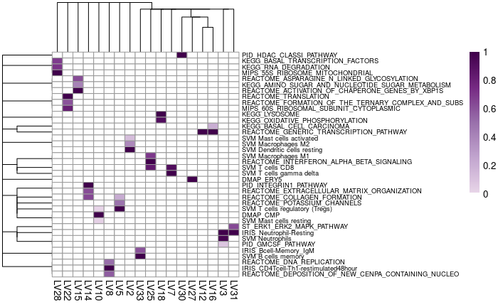

```r
PLIER::plotU(nares.plier, fontsize_row = 7)
```

To summarize *some* of these results:

- A latent variable associated with extracellular matrix formation is captured. `LV14` is associated with [`REACTOME_EXTRACELLULAR_MATRIX_ORGANIZATION`](http://software.broadinstitute.org/gsea/msigdb/cards/REACTOME_EXTRACELLULAR_MATRIX_ORGANIZATION.html), [`REACTOME_COLLAGEN_FORMATION`](http://software.broadinstitute.org/gsea/msigdb/cards/REACTOME_COLLAGEN_FORMATION.html), and [`PID_INTEGRIN1_PATHWAY`](http://software.broadinstitute.org/gsea/msigdb/cards/PID_INTEGRIN1_PATHWAY.html).
- There’s a neutrophil-associated LV, `LV3`.
- Interferon signaling is probably captured by `LV25`, but two immune cell types, M1 macrophages and CD8 T cells, are also associated with this LV. This is likely due to their production of or activation by IFN and we saw a bit of this overlap with cell types in other models (SLE WB, recount2).

```r
# save U plot to file
pdf(file.path(plot.dir, "NARES_U_plot.pdf"), height = 5, width = 7)
PLIER::plotU(nares.plier, fontsize_row = 8, fontsize_col = 8)
dev.off()
```

#### What proportion of the pathways input into the PLIER model are significantly associated with at least one LV?

```r
coverage.results <- GetPathwayCoverage(nares.plier)  # FDR < 0.05 by default
coverage.results$pathway
```

```
[1] 0.09394904
```

Less than 10% of the pathways we are interested in are significantly associated with a latent variable.

#### How sparse is U?

Take into account *all* pathways

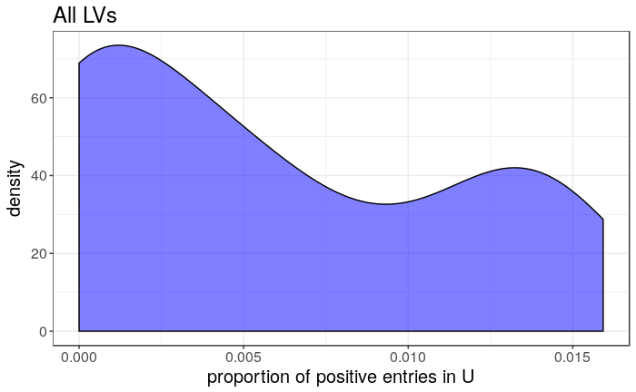

```r
u.sparsity.all <- CalculateUSparsity(nares.plier,
                                     significant.only = FALSE)
ggplot2::ggplot(as.data.frame(u.sparsity.all),
                ggplot2::aes(x = u.sparsity.all)) +
  ggplot2::geom_density(fill = "blue", alpha = 0.5) +
  ggplot2::theme_bw() +
  ggplot2::labs(x = "proportion of positive entries in U",
                title = "All LVs") +
  ggplot2::theme(text = ggplot2::element_text(size = 15))
```

```r
summary(u.sparsity.all)
```

```
    Min.  1st Qu.   Median     Mean  3rd Qu.     Max.
0.000000 0.000000 0.004777 0.005761 0.011943 0.015924
```

```r
plot.file <- file.path(plot.dir, "NARES_U_sparsity_all.png")
ggplot2::ggsave(plot.file, plot = ggplot2::last_plot())
```

What proportion of entries in the U matrix for each LV are significantly associated with that LV?

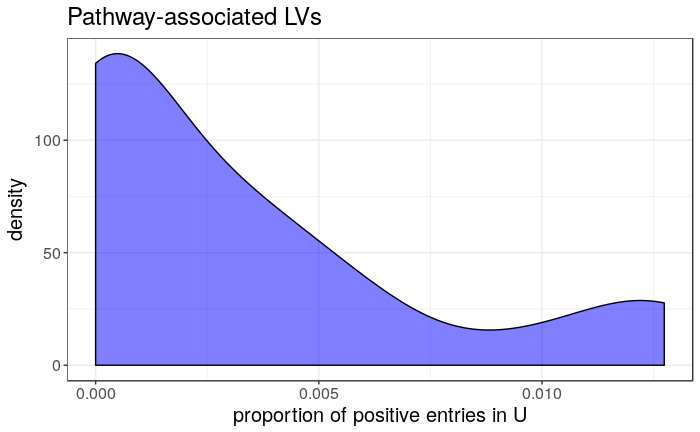

```r
u.sparsity.sig <- CalculateUSparsity(nares.plier,
                                     significant.only = TRUE)
ggplot2::ggplot(as.data.frame(u.sparsity.sig),
                ggplot2::aes(x = u.sparsity.sig)) +
  ggplot2::geom_density(fill = "blue", alpha = 0.5) +
  ggplot2::theme_bw() +
  ggplot2::labs(x = "proportion of positive entries in U",
                title = "Pathway-associated LVs")  +
  ggplot2::theme(text = ggplot2::element_text(size = 15))
```

```r
summary(u.sparsity.sig)
```

```
    Min.  1st Qu.   Median     Mean  3rd Qu.     Max.
0.000000 0.000000 0.001592 0.003185 0.004777 0.012739
```

```r
plot.file <- file.path(plot.dir, "NARES_U_sparsity_significant.png")
ggplot2::ggsave(plot.file, plot = ggplot2::last_plot())
```